### Predicting Weight Lifting Exercise Quality

#### Synopsis

Physical exercise (weight-lifting) data from the Human Activity Recognition Project was used to develop a predictive model capable of producing accurate predictions of the quality of exercise performance, based on the data from sensors worn by human subjects performing the exercise.

- Exploratory data analysis was performed to eliminate potential confounders and near-zero variance sensor variables.
- Both random forest and gradient boost prediction models were developed and their performance was determined/compared using cross validation.
- A random forest model using all useful sensor variables as predictors achieved a greater than 99% overall prediction accuracy against a (30%) hold out data set.
- An ad-hoc ensembling technique was used to verify that both the random forest and gradient boost models produced the same predictions when run against a 20 sample set of data for which the target class was not known.

#### Data Processing

##### Download and Read the Data

The data used in this analysis is drawn from the Weight Lifting Exercises Dataset from the [Human Activity Recognition Project](http://groupware.les.inf.puc-rio.br/har). For the purposes of this exercise, the data have been split into a *training* data set that includes approximately 20,000 observations of 159 potential predictor variables, plus a *classe* variable that denotes the five different manners in which a specific weight-lifting exercise can be performed ([1](http://groupware.les.inf.puc-rio.br/public/papers/2013.Velloso.QAR-WLE.pdf)), and a testing data set that includes 20 samples for which the *classe* variable is to be determined by a predictive model, using some or all of the 159 potential predictor variables.

```r
download.file("https://d396qusza40orc.cloudfront.net/predmachlearn/pml-training.csv", "pml-training.csv", method="curl")
dateTrainingDownloaded <- date()
download.file("https://d396qusza40orc.cloudfront.net/predmachlearn/pml-testing.csv", "pml-testing.csv", method="curl")
dateTestDownloaded <- date()
raw.data <- read.csv("pml-training.csv", na.strings = c("NA",""), stringsAsFactors=TRUE);
raw.test <- read.csv("pml-testing.csv", na.strings = c("NA",""), stringsAsFactors=TRUE);
dim(raw.data); dim(raw.test);
```

```
## [1] 19622   160
```

```
## [1]  20 160
```

The training data was downloaded on **Fri Aug 15 10:49:50 2014** and the test data was downloaded on **Fri Aug 15 10:49:51 2014**.

##### Exploratory Data Analysis and Cleaning the Data

A review of the training data shows seven (7) non-sensor variables (e.g. *user_name*, various timestamps), 152 sensor variables and the “target” variable, *classe*.

Using purely sensor variables, for predicting the manner in which a specific weight-lifting exercise was performed, is intuitively satisfying, since it eliminates any confounding influence that the non-sensor variables might introduce.

In addition, a large number of the sensor variables contain little or no data (i.e. they have a very high proportion of NA’s). Since, correspondingly, these sensor variables possess little predictive power, they are eliminated from the training set.

The following R code:

1. Removes the non-sensor variables (likely confounders)
2. Removes sensor variables with very little data (>95% NA)

```r
data <- raw.data[, -c(1:7)]
na.density <- apply(data, 2, function(x) mean(is.na(x)))
high.na.variables <- names(na.density[na.density > 0.95])
qar <- data[ , -which(names(data) %in% high.na.variables)]
```

#### Cross Validation

In order to perform cross-validation within the training data set provided, and to validate/confirm the out-of-sample error for the predictive model, the training data is split into a model training data set and a model testing (hold out) data set. The *caret* package is used to partition the data into 70% training and 30% testing.

```r
set.seed(8484)
inTrain <- createDataPartition(y=qar$classe, p=0.70, list=FALSE)
training <- qar[inTrain, ]
testing <- qar[-inTrain, ]
dim(training); dim(testing)
```

```
## [1] 13737    53
```

```
## [1] 5885   53
```

#### Building the Predictive Model

Based on the success of boosting, random forests and model ensembling in winning Kaggle and other prediction contests (2), a random forest and a gradient boost model were built/trained and their accuracy against the hold out (testing) data set was evaluated to assess their performance.

##### Random Forest

The initial random forest model is built using all of the “useful” sensor variables, as determined by exploratory data analysis (see above). Note that **additional bootstrap cross validation** is inherent in random forest models: “About one-third of the cases are left out of the bootstrap sample and not used in the construction of the kth tree.” ([3](http://www.stat.berkeley.edu/~breiman/RandomForests/cc_home.htm#ooberr))

```r
set.seed(33833) ## for reproducability
rf.fit <- randomForest(classe ~ ., data=training, importance=TRUE)
```

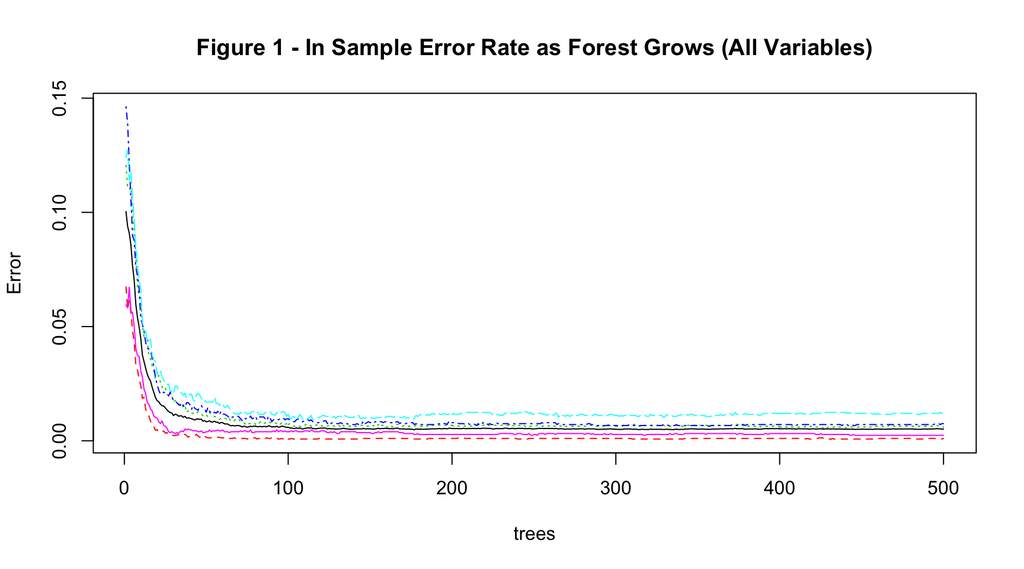

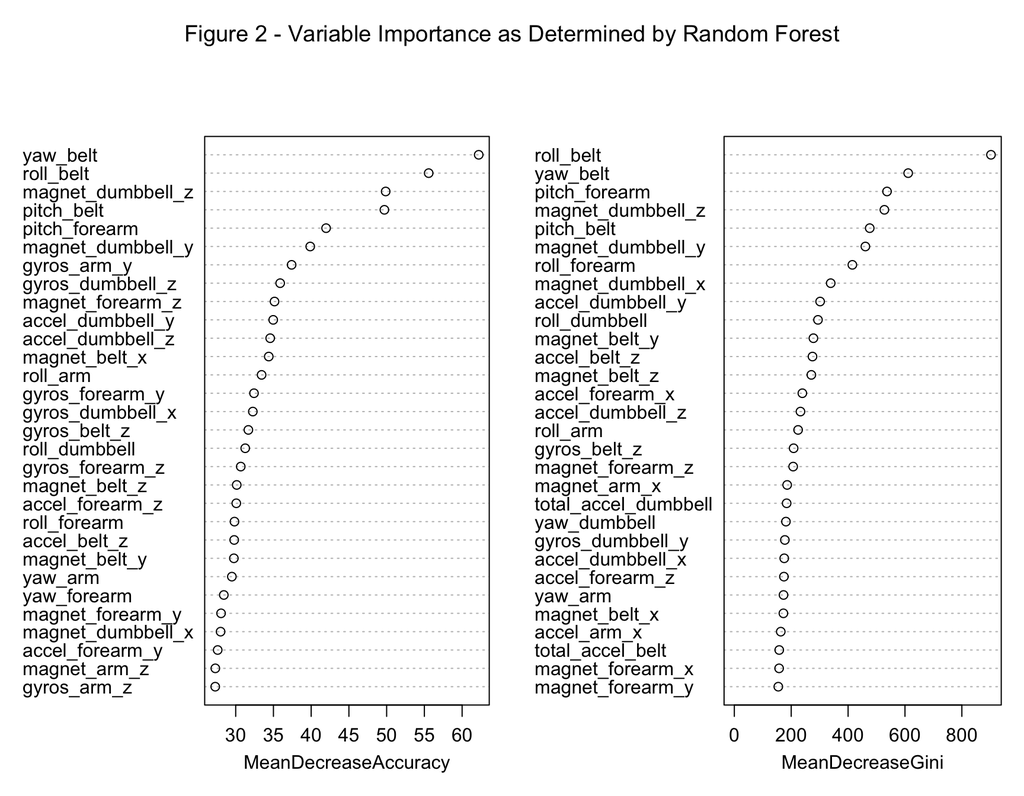

Figure 2 provides information on the relative importance of the various sensor variables with respect to their predictive performace. We reduce the number of variables to the most important ones, based on the location of the “elbow” in the Gini importance curve in Figure 2, and rebuild/train the random forest model. We will subsequently review the effect of using the smaller set of predictors (which may help avoid overfitting) on model accuracy (see below).

```r
imp <- data.frame(importance(rf.fit))
no.of.variables <- 18
top.variables <- rownames(imp[with(imp, order(-MeanDecreaseGini)), ])[1:no.of.variables]
train2 <- training[ , which(names(training) %in% c(top.variables, "classe"))]
set.seed(33833)
rf.imp.fit <- randomForest(classe ~ ., data=train2)
```

[figure not shown]

[output not shown]

```
## Accuracy
##        1
```

```
## Accuracy
##        1
```

Thus, we see that both random forest models (one using all of the sensor variables and one using only the most important sensor variables), achieve the same (zero) in-sample error. Their performance with respect to out-of-sample error, which we expect to be higher (i.e. reduced accuracy), is evaluated below.

##### Gradient Boosting

Boosting is also a predictive modelling approach that is known to perform well, in general, so a boosting model (gbm) is built/trained to provide a second model that can be:

1. Compared to the random forest model developed above with respect to predictive accuracy against the hold out data set, and
2. Used in an “ad-hoc” ensembling technique that compares its predictions on the 20 sample testing set with the predictions of the random forest model.

```r
set.seed(88388)
gbm.fit <- train(classe ~ ., method="gbm", data=training, verbose=FALSE)
```

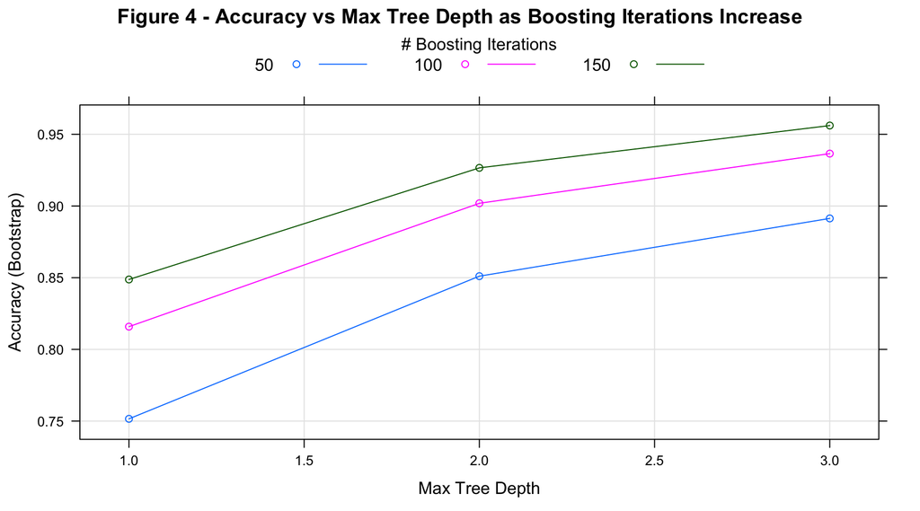

```r
gbm.ise <- confusionMatrix(training$classe, predict(gbm.fit, training[,-53]))
gbm.ise$table; gbm.ise$overall[1]
```

```
##           Reference
## Prediction    A    B    C    D    E
##          A 3872   21    7    6    0
##          B   56 2556   44    1    1
##          C    0   51 2321   21    3
##          D    1    5   71 2167    8
##          E    2   15   19   25 2464
```

```
## Accuracy
##    0.974
```

Note that the Gradient Boost model has a lower in-sample accuracy than the random forest models (97.4% vs 100%)

#### Determining Model Performance (Out-of-Sample Error)

The out-of-sample error performance of each model is determined by computing a confusion matrix that compares the model prediction with the “known truth” from the model testing (hold out) data set.

Determining the out-of-sample performance for the random forest model with all variables:

```r
rf.ose <- confusionMatrix(testing$classe, predict(rf.fit, testing[,-53]))
rf.ose$table; rf.ose$overall[1]
```

```
##           Reference
## Prediction    A    B    C    D    E
##          A 1673    1    0    0    0
##          B    4 1134    1    0    0
##          C    0    3 1023    0    0
##          D    0    0    5  958    1
##          E    0    0    0    3 1079
```

```
## Accuracy
##   0.9969
```

Determining the out-of-sample performance for the random forest model with the most important variables:

```r
test2 <- testing[ , which(names(testing) %in% c(top.variables, "classe"))]
rf.imp.ose <- confusionMatrix(test2$classe, predict(rf.imp.fit, test2[,-19]))
rf.imp.ose$table; rf.imp.ose$overall[1]
```

```
##           Reference
## Prediction    A    B    C    D    E
##          A 1672    1    1    0    0
##          B    6 1127    6    0    0
##          C    0    3 1020    3    0
##          D    0    0    5  955    4
##          E    0    0    3    3 1076
```

```
## Accuracy
##   0.9941
```

Determining the out-of-sample performance for the gradient boost model with all variables:

```r
gbm.ose <- confusionMatrix(testing$classe, predict(gbm.fit, testing[,-53]))
gbm.ose$table; gbm.ose$overall[1]
```

```
##           Reference
## Prediction    A    B    C    D    E
##          A 1653   12    4    4    1
##          B   46 1064   26    1    2
##          C    0   32  979   12    3
##          D    0    6   25  929    4
##          E    2    9   14   15 1042
```

```
## Accuracy
##    0.963
```

The random forest model that uses all of the useful sensor variables has the lowest out-of-sample error rate (0.31%), followed by the random forest model that uses the most important sensor variables (0.59%), followed by the gradient boost model (3.7%).

**As a result of this analysis, the random forest model that uses all of the useful sensor variables is selected as the model of choice.**

#### Predicting the Testing Set Classifications

The (all variable) random forest model and the gradient boost model are used to predict the *classe* variable for the original testing data set with the 20 samples for which the *classe* is unknown (and is to be predicted as part of this exercise). Finally, the predictions from the two different models are compared in an ad-hoc ensembling technique

Pre-processing of the test data to remove non-sensor variables and sensor variables with >95% NA’s:

```r
test.data <- raw.test[, -c(1:7)]
test.qar <- test.data[ , -which(names(test.data) %in% high.na.variables)]
```

Predict the *classe* for the 20 samples using the random forest model:

```r
answers.rf <- as.character(predict(rf.fit, test.qar[-53])); answers.rf
```

```
##  [1] "B" "A" "B" "A" "A" "E" "D" "B" "A" "A" "B" "C" "B" "A" "E" "E" "A"
## [18] "B" "B" "B"
```

Predict the *classe* for the 20 samples using the gradient boost model:

```r
answers.gbm <- as.character(predict(gbm.fit, test.qar[-53])); answers.gbm
```

```
##  [1] "B" "A" "B" "A" "A" "E" "D" "B" "A" "A" "B" "C" "B" "A" "E" "E" "A"
## [18] "B" "B" "B"
```

Compare the predictions of the two different models:

```r
setdiff(answers.rf, answers.gbm); setequal(answers.rf, answers.gbm)
```

```
## character(0)
```

```
## [1] TRUE
```

#### Conclusion

The “ad-hoc” ensembling technique of comparing the predictions from the two different types of models indicates that both the random forest and gradient boost models yield identical results, which increases the confidence that the model of choice (random forest with all useful sensor variables) produces accurate predictions.